# Gapminder-MPG-Data-Visualisation

## 3.5.1

3.5.1: Questions 1: It is advisable facet will be used for a discrete variable because for a continuous variable, it divides the plot into individual values holding data points

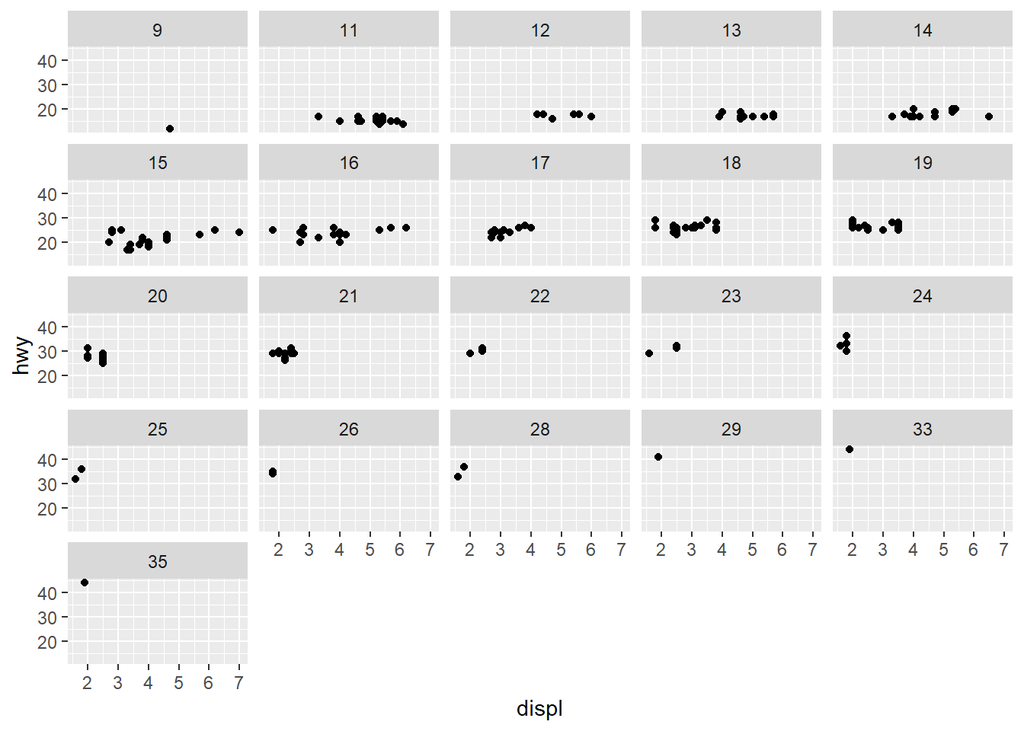

```r
ggplot(mpg, aes(displ, hwy)) + geom_point() + facet_wrap(~ cty)
```

3.5.1: Questions 2: Not very sure why, but looking at the plot seems facets are empty when there is no data for that combination. For example, it seems “rear wheel drive” has no 4 and 5 cylinders listed in the data so as ‘all wheel drive’ has no 5 cylinder data point listed.

3.5.1: Questions 4: Faceting I think it is easier to examine the individual categorical classes. Coloring I think it is easier to see how the categorical classes are clustered overall plane. Larger datasets I think it will be more likely that one will want to see the overall clustering instead of the individual point clouds.

## 3.6.1

3.6.1: Questions 1:

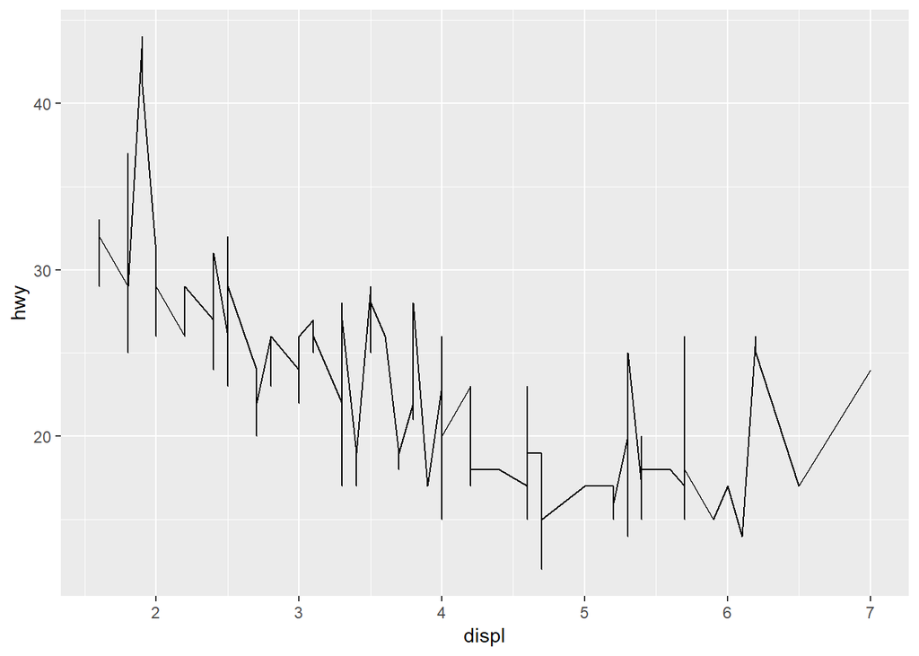

```r
par (mfrow= c(2,2))
#For a line chart, you will use geom_line
ggplot(mpg, aes(displ, hwy)) + geom_line()
```

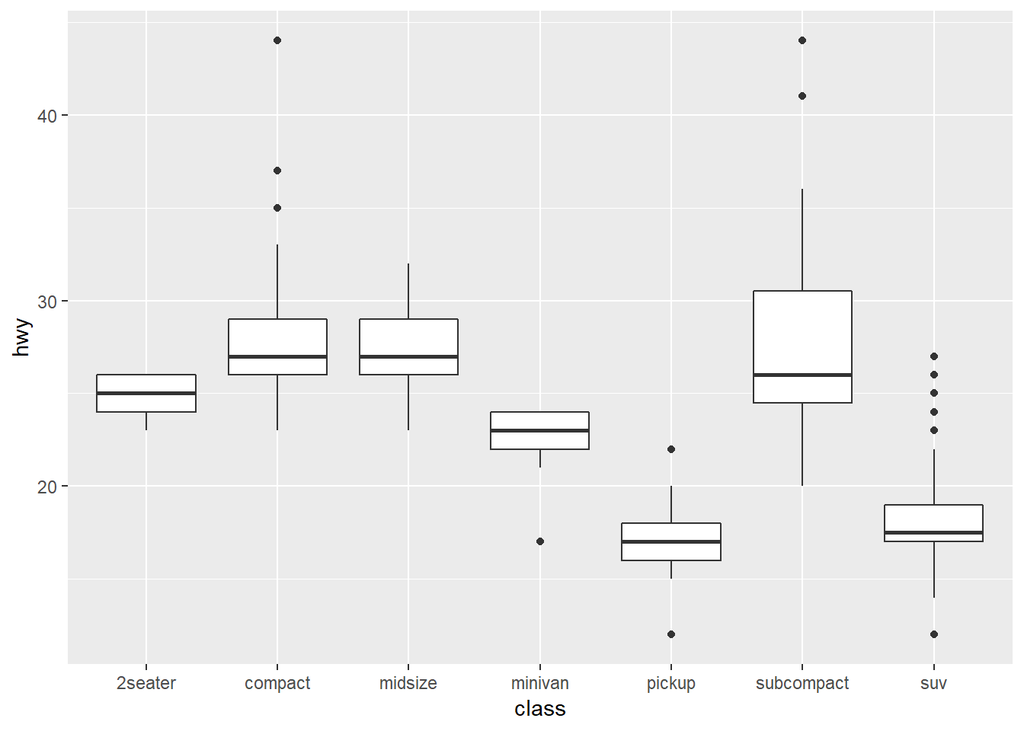

```r
#For a boxplot, you will use geom_boxplot
ggplot(mpg, aes(class, hwy)) + geom_boxplot()
```

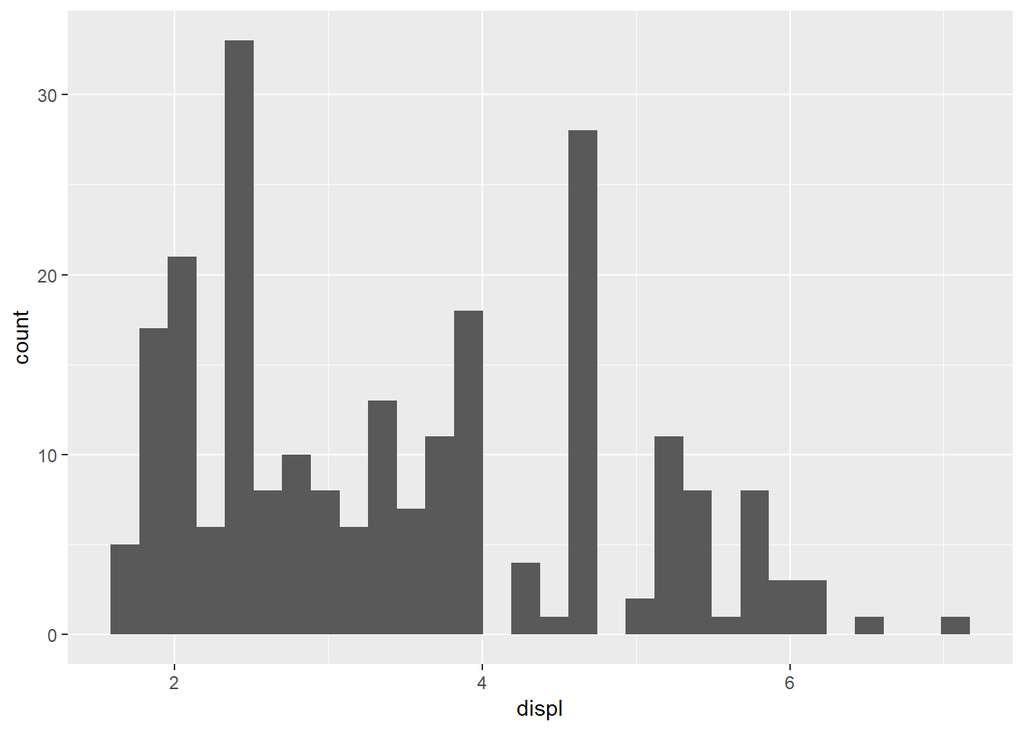

```r
#For a histogram, you will use  geom_histogram
ggplot(mpg, aes(displ)) + geom_histogram()
```

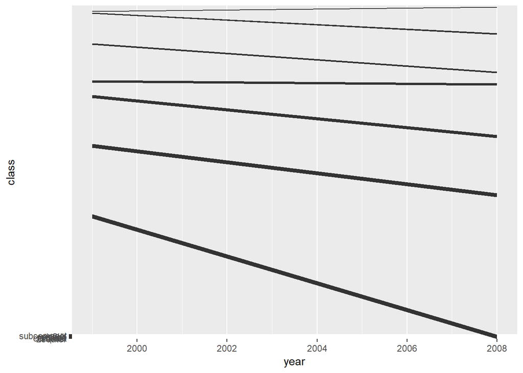

```r
#For an area chart, you will use geom_area
ggplot(mpg, aes(year, class)) + geom_area()
```

3.6.1: Questions 1: Based on the earlier examples in the section, when I did run the code in my mind I anticipated three lines been produced with points around them. This is because of the geom_smooth and geom_point but did not expect them to be as smooth as earlier examples because of the se=False.

3.6.1: Questions 2: Based on the earlier examples in the section, when I did run the code in my mind I anticipated three different colored lines been produced with points around them. I expected these because of color = drv, geom_smooth, and geom_point but did not expect them to be wrapped in grey as earlier examples because of the se=False. My prediction was pretty much on point but not sure I could have predicted it if I had not referred back to the plots in the section.

3.6.1: Questions 3: Obviously, it is meant to tell ggplot not to show legend. Removing it incorporates legend to the plot. It was not used in the earlier because you did not want to show legend since it would have been redundant

3.6.1: Questions 4: I am sure se represent sample error, which plays a role in calculating the confident interval, so am sure it produces the grey area around the line, which might be the confident interval.

3.6.1: Questions 5: I think they will produce the same outcome because in the first code the layers inherit the properties from the earlier stated aesthetic but the second one repeats them for every geom.

3.6.1: Questions 6: I read online that I could merge all these plots together with help of these two packages, which are gridExtra and cowplot, host plot_grid.

```r
library(gridExtra)
```

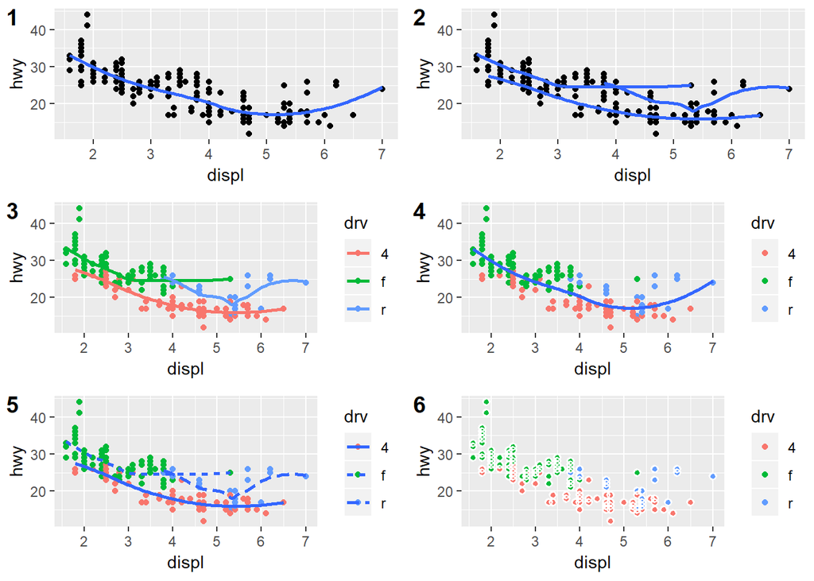

```r
library(cowplot)
plot_num_1 <- ggplot(mpg, aes(x = displ, y = hwy)) + geom_point() + geom_smooth(se = FALSE)
plot_num_2 <- ggplot(mpg, aes(x = displ, y = hwy)) + geom_point() + geom_smooth(aes(group = drv), se = FALSE)
plot_num_3 <- ggplot(mpg, aes(x = displ, y = hwy, color=drv)) + geom_point() + geom_smooth(se = FALSE)
plot_num_4 <- ggplot(mpg, aes(x = displ, y = hwy)) + geom_point(aes(color=drv)) + geom_smooth(se = FALSE)
plot_num_5 <- ggplot(mpg, aes(x = displ, y = hwy)) + geom_point(aes(color=drv)) + geom_smooth(se = FALSE, aes(linetype = drv))
plot_num_6 <- ggplot(mpg, aes(x = displ, y = hwy)) + geom_point(aes(color=drv)) + geom_point(shape = 21, color = "white", stroke = 1)
theme_set(theme_gray())
plot_grid(plot_num_1, plot_num_2, plot_num_3, plot_num_4, plot_num_5, plot_num_6, labels=c("1","2","3", "4","5","6"), ncol=2, nrow = 3)
```

## 3.8.1

3.8.1: Questions 1: Not sure of what is wrong with the plot but from my understanding of section I will say most of the points are overlapping (the problem of overplotting), that can be confirmed looking at the number of points showing on the plot with the knowledge of the number of data points mpg has. The problem can be rectified by introducing jitter into the plot

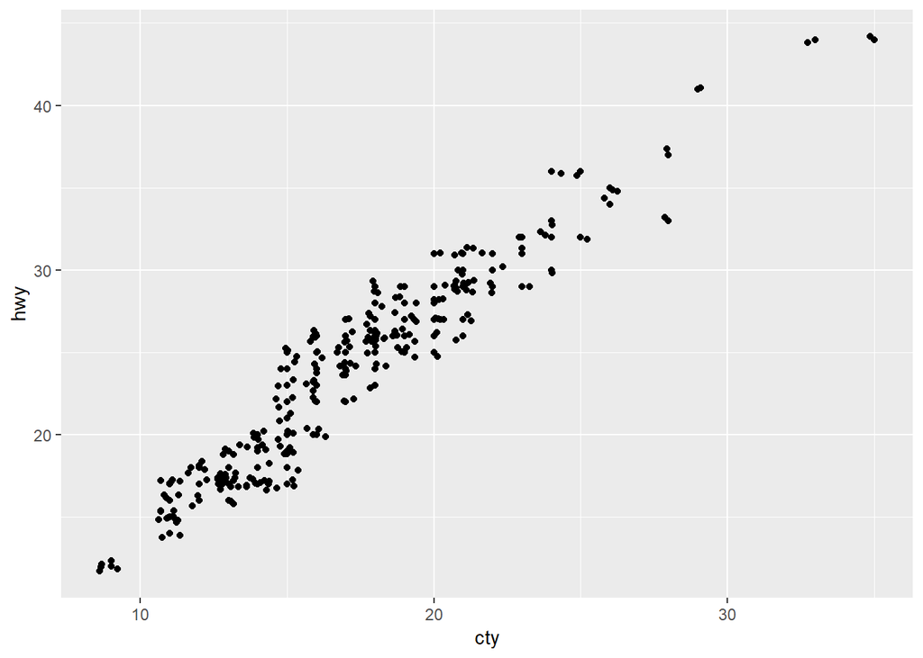

```r
ggplot(mpg, aes(x = cty, y = hwy)) + geom_point() + geom_jitter()
```

3.8.1: Questions 2: width and height

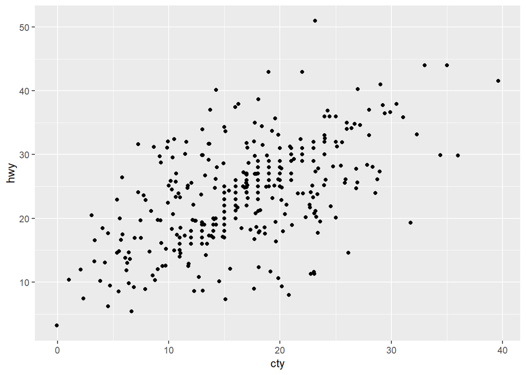

```r
ggplot(mpg, aes(x = cty, y = hwy)) + geom_point() + geom_jitter(width = 10, height = 10)
```